# Part II - (Ford GoBike System Data Slide Show)

## by (Robertson Otoo Asare)

## Dataset Overview

This data set includes information about individual rides made in a bike-sharing system covering the greater San Francisco Bay area which has about 500,0000 rides since it launch in 2017. The dataset is in csv format downloaded from the udacity classroom. Download here.  
Visualization are created from preliminary wrangling and cleaning process to facilitate exploration analysis to discover usage pattern.

## User Types and Their weekly Usage

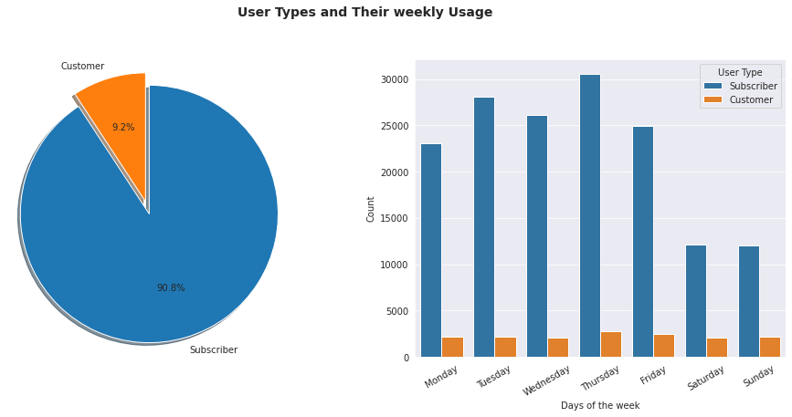

## Average Weekday Trip Duration for Customers and Subscribers

Subscribers ride much shorter trips compared to customers on each day of the week. Both user types had an obvious increase of trip duration on weekends, especially customers. Subscriber usage was more efficient than customers overall and maintained a stable average duration Monday through Friday.

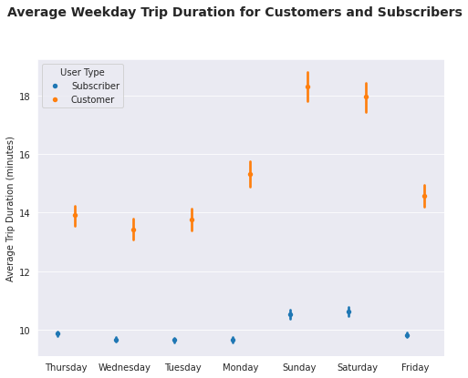

## Usage between customers and subscribers on daily basis

Subscriber usage goes up when people go to work in the morning and getting off work in the afternoon. Such was not observed among customers who tend to ride most in the evening and afternoon.

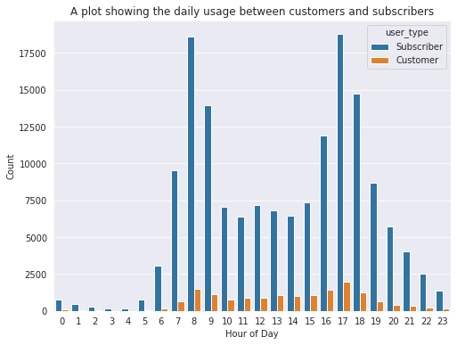